# Analysis of @WeRateDogs tweets

Parth Thakur

11 September 2018

[Github](https://github.com/ParthThakur/Wrangling-and-Analyzing-WeRateDogs-twitter-archive)

Our dataset has data for over 1500 tweets by @WeRateDogs.

@WeRateDogs is a twitter account that rates dogs on the internet on a scale of 10. But all the dogs are rated above 10. Why? [Because they are good dogs, Brent.](https://knowyourmeme.com/memes/theyre-good-dogs-brent)

This dataset originally contained over 2500 tweets. I used data wrangling techniques to filter out data not needed for this analysis. The wrangling process can be found [here.](https://parththakur.page.link/wrangling)

The data in our dataset looks something like this:

```
##                              timestamp  dog_name rating_numerator
## 892177421306343424 2017-08-01 00:17:27     Tilly               13
## 891815181378084864 2017-07-31 00:18:03    Archie               12
## 891689557279858688 2017-07-30 15:58:51     Darla               13
## 891327558926688256 2017-07-29 16:00:24 Frnanklin               12
## 891087950875897856 2017-07-29 00:08:17                         13
## 890971913173991424 2017-07-28 16:27:12       Jax               13
##                                   dog_breed dog_stage
## 892177421306343424                Chihuahua
## 891815181378084864                Chihuahua
## 891689557279858688       Labrador Retriever
## 891327558926688256                   Basset
## 891087950875897856 Chesapeake Bay Retriever
## 890971913173991424              Appenzeller
##                                                                                                                                                           text
```

[output cut: 20 more lines]

Let me start by checking some descriptive statistics on the important columns.

```
##     dog_name    rating_numerator              dog_breed
##         : 472   Min.   :  0.00   Golden Retriever  : 158
##  Cooper :  10   1st Qu.: 10.00   Labrador Retriever: 108
##  Lucy   :  10   Median : 11.00   Pembroke          :  95
##  Charlie:   9   Mean   : 11.48   Chihuahua         :  91
##  Oliver :   9   3rd Qu.: 12.00   Pug               :  62
##  Tucker :   9   Max.   :165.00   Toy Poodle        :  51
##  (Other):1166   NA's   :1        (Other)           :1120
##   dog_stage         retweet_count   favourite_count
##  Length:1685        Min.   :   12   Min.   :    80
##  Class :character   1st Qu.:  614   1st Qu.:  2086
##  Mode  :character   Median : 1369   Median :  4294
##                     Mean   : 2739   Mean   :  9136
##                     3rd Qu.: 3104   3rd Qu.: 11312
##                     Max.   :84548   Max.   :164603
##
```

Let me first take a look at the distribution of the ratings.

[figure not shown]

Looks like most of the ratings are below 15 with some significant outliers. Let me take a look at the outliers.

```
##    rating_numerator
## 1                84
## 2                75
## 3                27
## 4               165
## 5                50
## 6                99
## 7                80
## 8                45
## 9                60
## 10               44
## 11              143
## 12              121
## 13               26
## 14              144
```

[output cut: 17 more lines]

Looks like a bunch of them are ratings with a decimal point. Highlighting the fact that not all cleanliness issues can be fixed.  
Though most of them are true ratings. Must be exceptionally good dogs.

Now, I want to know tweeting habits of @WeRateDogs. Let’s check how much they tweeted over time.

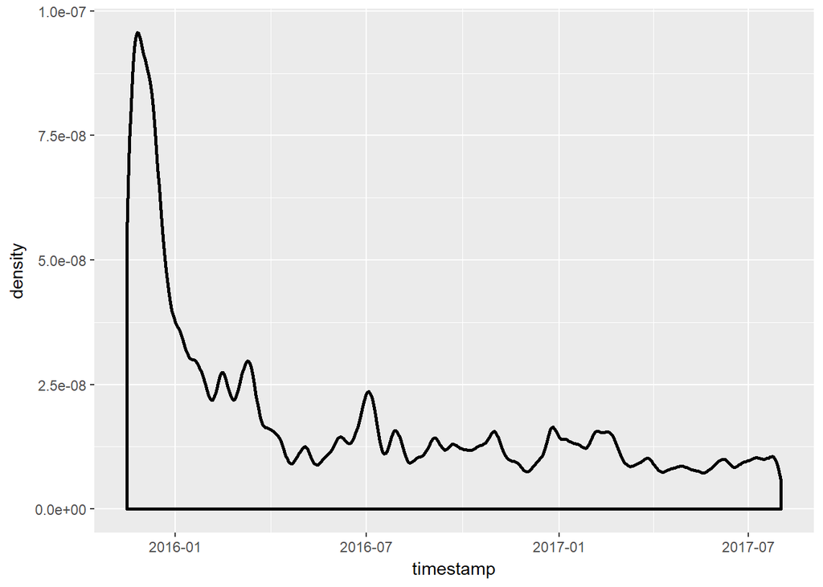

Looks like they had an exciting start! But the number of tweets gradually over time. I wonder if the tweeted a type of dog more than the other.

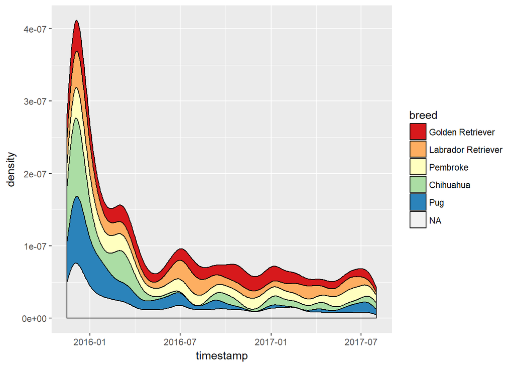

Looks like the distribution is fairly even. Pugs and Chihuahuas were the most common breeds at the begining, but Pugs seem to fave fallen in numbers near January 2017. Golden Retrievers seemed to be the most popular around that time.

Though no matter what breed, they are all good dogs. :D